# Title of Lecture

## Thinking Like a Bayesian

- We can also use this approach to combine analysis results.

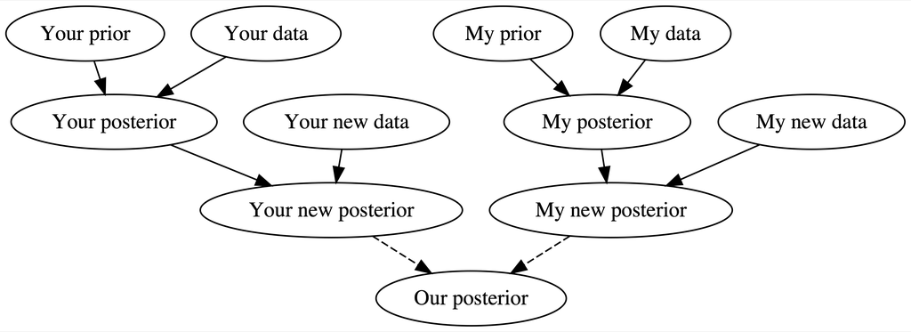

## Thinking Like a Bayesian

- We will use an example to work through Bayesian logic.
- The Collins Dictionary named “fake news” the 2017 term of the year.
  - Fake, misleading, and biased news has proliferated along with online news and social media platforms which allow users to post articles with little quality control.
- We want to flag articles as “real” or “fake.”
- We’ll examine a sample of 150 articles which were posted on Facebook and fact checked by five BuzzFeed journalists (Shu et al. 2017).

## Thinking Like a Bayesian

- Information about each article is stored in the `fake_news` dataset in the `bayesrules` package.

```r
fake_news <- bayesrules::fake_news
print(colnames(fake_news))
```

```
 [1] "title"                   "text"
 [3] "url"                     "authors"
 [5] "type"                    "title_words"
 [7] "text_words"              "title_char"
 [9] "text_char"               "title_caps"
[11] "text_caps"               "title_caps_percent"
[13] "text_caps_percent"       "title_excl"
[15] "text_excl"               "title_excl_percent"
[17] "text_excl_percent"       "title_has_excl"
[19] "anger"                   "anticipation"
[21] "disgust"                 "fear"
[23] "joy"                     "sadness"
[25] "surprise"                "trust"
[27] "negative"                "positive"
[29] "text_syllables"          "text_syllables_per_word"
```

## Thinking Like a Bayesian

- We could build a simple news filter which uses the following rule: since most articles are real, we should read and believe all articles.
  - While this filter would solve the problem of disregarding real articles, we would read lots of fake news.
  - It also only takes into account the overall rates of, not the typical features of, real and fake news.

## Thinking Like a Bayesian

- Suppose that the most recent article posted to a social media platform is titled: *The president has a funny secret!*
  - Some features of this title probably set off some red flags.
  - For example, the usage of an exclamation point might seem like an odd choice for a real news article.
- In the dataset, what is the split of real and fake articles?

| type | n | percent |
| --- | --- | --- |
| fake | 60 | 0.4 |
| real | 90 | 0.6 |

## Thinking Like a Bayesian

- In the dataset, what is the split of real and fake articles?

| type | n | percent |
| --- | --- | --- |
| fake | 60 | 0.4 |
| real | 90 | 0.6 |

- Our data backs up our instinct on the article,

|  | title_has_excl | fake | real |
| --- | --- | --- | --- |
| 1 | FALSE | 73.33% (44) | 97.78% (88) |
| 2 | TRUE | 26.67% (16) | 2.22% (2) |

- In this dataset, 26.67% (16 of 60) of fake news titles but only 2.22% (2 of 90) of real news titles use an exclamation point.

## Thinking Like a Bayesian

- We now have two pieces of contradictory information.
  - Our prior information suggested that incoming articles are most likely real.
  - However, the exclamation point data is more consistent with fake news.

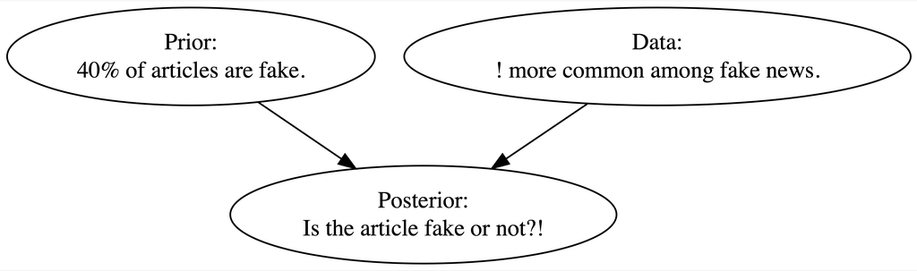

- Thinking like Bayesians, we know that balancing both pieces of information is important in developing a posterior understanding of whether the article is fake.

## Building a Bayesian Model

- Our fake news analysis studies two variables:
  - an article’s fake vs real status and
  - its use of exclamation points.
- We can represent the randomness in these variables using probability models.
- We will now build:
  - a prior probability model for our prior understanding of whether the most recent article is fake;
  - a model for interpreting the exclamation point data; and, eventually,
  - a posterior probability model which summarizes the posterior plausibility that the article is fake.

## Building a Bayesian Model

- Let’s now formalize our prior understanding of whether the new article is fake.
- Based on our `fake_news` data, we saw that 40% of articles are fake and 60% are real.
  - Before reading the new article, there’s a 0.4 prior probability that it’s fake and a 0.6 prior probability it’s not.

- Remember that a valid probability model must:
  1. account for all possible events (all articles must be fake or real);
  2. it assigns prior probabilities to each event; and
  3. the probabilities sum to one.

## Building a Bayesian Model

- Now we will summarize the insights from the data we collected on the new article.
  - We want to formalize our observation that the exclamation point data is more compatible with fake news than with real news.

| title_has_excl | fake | real |
| --- | --- | --- |
| FALSE | 73.3% (44) | 97.8% (88) |
| TRUE | 26.7% (16) | 2.2% (2) |

- We have the following conditional probabilities:
  - If an article is fake ($B$), then there’s a roughly 26.67% chance it uses exclamation points in the title.
  - If an article is real ($B^c$), then there’s only a roughly 2.22% chance it uses exclamation points.

## Building a Bayesian Model

- We have the following conditional probabilities:
  - If an article is fake ($B$), then there’s a roughly 26.67% chance it uses exclamation points in the title.
  - If an article is real ($B^c$), then there’s only a roughly 2.22% chance it uses exclamation points.
- Looking at the probabilities, we can see that 26.67% of fake articles vs. 2.22% of real articles use exclamation points.
  - Exclamation point usage is much more likely among fake news than real news.
  - We have evidence that the article is fake.

## Building a Bayesian Model

- Note that we know that the incoming article used exclamation points ($A$), but we do not actually know if the article is fake ($B$ or $B^c$).
- In this case, we compared $P[A|B]$ and $P[A|B^c]$ to ascertain the relative likelihood of observing $A$ under different scenarios.

$$L\left[B|A\right] = P\left[A|B\right] \text{ and } L\left[B^c|A\right] = P\left[A|B^c\right]$$

| Event | *B* | *B<sup>c</sup>* | Total |
| --- | --- | --- | --- |
| Prior Probability | 0.4 | 0.6 | 1.0 |
| Likelihood | 0.2667 | 0.0222 | 0.2889 |

- It is important for us to note that the likelihood function is *not* a probability function.
  - This is a framework to compare the relative comparability of our exclamation point data with $B$ and $B^c$.

## Building a Bayesian Model

| Event | *B* (fake) | *B<sup>c</sup>* (real) | Total |
| --- | --- | --- | --- |
| Prior Probability | 0.4 | 0.6 | 1.0 |
| Likelihood | 0.2667 | 0.0222 | 0.2889 |

- The prior evidence suggested the article is most likely real,

$$P[B] = 0.4 < P[B^c] = 0.6$$

- The data, however, is more consistent with the article being fake,

$$L[B|A] = 0.2667 > L[B^c|A] = 0.0222$$

## Building a Bayesian Model

- We can summarize our probabilities in a table, but some calculations are required.
- Here’s what we know,

|  | $B$ | $B^c$ | Total |
| --- | --- | --- | --- |
| $A$ |  |  |  |
| $A^c$ |  |  |  |
| **Total** | 0.4 | 0.6 | 1 |

- We also know $P[A|B] = 0.2667$ and $P[A|B^c]=0.0222$.
- Thus,

$$\begin{align*}
P[A \cap B] &= P[A|B] \times P[B] \\
&= 0.2667 \times 0.4 \\
&= 0.1067
\end{align*}$$

## Building a Bayesian Model

- Here’s what we know,

|  | $B$ | $B^c$ | Total |
| --- | --- | --- | --- |
| $A$ | 0.1067 |  |  |
| $A^c$ |  |  |  |
| **Total** | 0.4 | 0.6 | 1 |

- We also know $P[A|B] = 0.2667$ and $P[A|B^c]=0.0222$.
- Thus,

$$\begin{align*}
P[A^c \cap B] &= P(A^c|B) \times P[B] \\
&= (1-P[A|B]) \times P[B] \\
&= (1-0.2667) \times 0.4 \\
&= 0.2933
\end{align*}$$

## Building a Bayesian Model

- Here’s what we know,

|  | $B$ | $B^c$ | Total |
| --- | --- | --- | --- |
| $A$ | 0.1067 |  |  |
| $A^c$ | 0.2933 |  |  |
| **Total** | 0.4 | 0.6 | 1 |

- We also know $P[A|B] = 0.2667$ and $P[A|B^c]=0.0222$.
- Thus,

$$\begin{align*}
P[A \cap B^c] &= P[A|B^c] \times P[B^c] \\
&= 0.0222 \times 0.6 \\
&= 0.0133
\end{align*}$$

## Building a Bayesian Model

- Here’s what we know,

|  | $B$ | $B^c$ | Total |
| --- | --- | --- | --- |
| $A$ | 0.1067 | 0.0133 |  |
| $A^c$ | 0.2933 |  |  |
| **Total** | 0.4 | 0.6 | 1 |

- We also know $P[A|B] = 0.2667$ and $P[A|B^c]=0.0222$.
- Thus,

$$\begin{align*}
P[A^c \cap B^c] &= P[A^c|B^c] \times P[B^c] \\
&= 0.9778 \times 0.6 \\
&= 0.5867
\end{align*}$$

## Building a Bayesian Model

- Here’s what we know,

|  | $B$ | $B^c$ | Total |
| --- | --- | --- | --- |
| $A$ | 0.1067 | 0.0133 |  |
| $A^c$ | 0.2933 | 0.5867 |  |
| **Total** | 0.4 | 0.6 | 1 |

- Finally,

$$\begin{align*}
&P[A] = 0.1067 + 0.0133 = 0.12 \\
&P[A^c] = 0.2933 + 0.5867 = 0.88
\end{align*}$$

## Building a Bayesian Model

- Using rules of probability, we have completed the table.

|  | $B$ | $B^c$ | Total |
| --- | --- | --- | --- |
| $A$ | 0.1067 | 0.0133 | 0.12 |
| $A^c$ | 0.2933 | 0.5867 | 0.88 |
| **Total** | 0.4 | 0.6 | 1 |

## Building a Bayesian Model

- With more information, we can answer the question: what is the probability that the latest article is fake?
- We will use the posterior probability, $P[B|A]$, which is found using Bayes’ Rule.
- **Bayes’ Rule**: For events $A$ and $B$,

$$P[B|A] = \frac{P[A \cap B]}{P[A]} = \frac{P[B] \times L[B|A]}{P[A]}$$

- But really, we can think about it like this,

$$\text{posterior} = \frac{\text{prior} \times \text{likelihood}}{\text{normalizing constant}}$$

## Example Set Up

- In 1996, Gary Kasparov played a six-game chess match against the IBM supercomputer Deep Blue.
  - Of the six games, Kasparov won three, drew two, and lost one.
  - Thus, Kasparov won the overall match.
- Kasparov and Deep Blue were to meet again for a six-game match in 1997.
- Let $\pi$ denote Kasparov’s chances of winning any particular game in the re-match.
  - Thus, $\pi$ is a measure of his overall skill relative to Deep Blue.
  - Given the complexity of chess, machines, and humans, $\pi$ is unknown and can vary over time.
    - i.e., $\pi$ is a *random variable*.

## Example Set Up

- Our first step is to start with a prior model. This model
  - Identifies what values $\pi$ can take,
  - assigns a prior weight or probability to each, and
  - these probabilities sum to 1.
- Based on what we were told, the prior model for $\pi$ in our example,

| $\pi$ | 0.2 | 0.5 | 0.8 | Total |
| --- | --- | --- | --- | --- |
| $f(\pi)$ | 0.10 | 0.25 | 0.65 | 1 |

- Note that this is an incredibly simple model.
  - The win probability can technically be any number $\in [0, 1]$.
  - However, this prior assumes that $\pi$ has a discrete set of possibilities: 20%, 50%, or 80%.

## Binomial Data Model

- We must make two assumptions about the chess match:
  - Games are independent (the outcome of one game does not influence the outcome of another).
  - Kasparov has an equal probability of winning any game in the match.
    - i.e., probability of winning does not increase or decrease as the match goes on.
- We will use a binomial model for this problem.
  - In our case,

$$Y|\pi \sim \text{Bin}(6, \pi)$$

## Binomial Data Model

- Let’s assume $\pi = 0.8$.
- The probability that he would win all 6 games is approximately 26%.

$$f(y=6|\pi=0.8) = {6 \choose 6} 0.8^6 (1-0.8)^{6-6},$$

```r
dbinom(6, 6, 0.8)
```

```
[1] 0.262144
```

## Binomial Data Model

- Let’s assume $\pi = 0.8$.
- The probability that he would win none of the games is approximately 0%.

$$f(y=0|\pi=0.8) = {6 \choose 0} 0.8^0 (1-0.8)^{6-0},$$

```r
dbinom(0, 6, 0.8)
```

```
[1] 6.4e-05
```

## Binomial Data Model

- Your turn!
- We want to reproduce Figure 2.5 from the [Bayes Rules! textbook (from Section 2.3.2)](https://www.bayesrulesbook.com/chapter-2#cousin-cole).

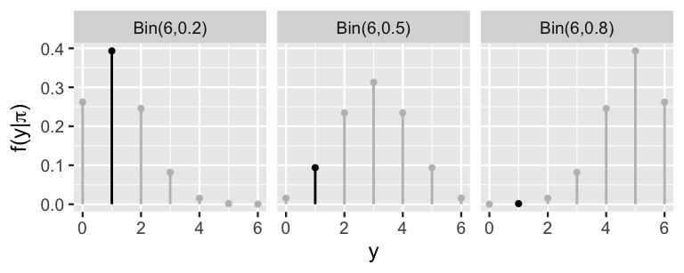

- Each group will complete the graph for a specified value of $\pi$.
  - Campus: $\pi=0.2$
  - Zoom 1: $\pi=0.5$
  - Zoom 2: $\pi=0.8$

## Binomial Data Model

- Note that the Binomial gives us the *theoretical* model of the data we might observe.
  - Kasparov only won one of the six games against Deep Blue in 1997 ($Y=1$).
- Next step: how compatible this particular data is with the various possible $\pi$?
  - What is the likelihood of Kasparov winning $Y=1$ game under each possible $\pi$?
- Recall, $f(y|\pi) = L(\pi|Y=y)$. When $Y=1$,

$$\begin{align*}
L(\pi | y = 1) &= f(y=1|\pi) \\
&= {6 \choose 1} \pi^1 (1-\pi)^6-1 \\
&= 6\pi(1-\pi)^5
\end{align*}$$

- Note that we do not expect all likelihoods to sum to 1.

## Binomial Data Model

- Your turn!
- Use your results from earlier to tell me the resulting likelihood values.

| $\pi$ | 0.2 | 0.5 | 0.8 |
| --- | --- | --- | --- |
| $L(\pi\|y=1)$ |  |  |  |

## Binomial Data Model

- Your turn!
- Use your results from earlier to tell me the resulting likelihood values.

| $\pi$ | 0.2 | 0.5 | 0.8 |
| --- | --- | --- | --- |
| $L(\pi\|y=1)$ | 0.3932 | 0.0938 | 0.0015 |

- As we can see, the likelihoods do not sum to 1.

## Normalizing Constant

- Bayes’ Rule requires three pieces of information:
  - Prior
  - Likelihood
  - Normalizing constant
- **Normalizing constant**: ensures that the sum of all probabilities is equal to 1.
  - It can be a scalar or a function.
  - Every probability distribution that does not sum to 1 will have a normalizing constant.

## Normalizing Constant

- We now must determine the total probability that Kasparov would win $Y=1$ games across all possible win probabilities $\pi$, $f(y=1)$.

$$\begin{align*}
f(y=1) =& \sum_{\pi} L(\pi |y=1)f(\pi) \\
=& L(\pi=0.2|y=1)f(\pi=0.2) + L(\pi=0.5|y=1)f(\pi=0.5) + \\
& L(\pi=0.8|y=1)f(\pi=0.8)
\end{align*}$$

- Work with your group to find the normalizing constant.

## Normalizing Constant

- We now must determine the total probability that Kasparov would win $Y=1$ games across all possible win probabilities $\pi$, $f(y=1)$.

$$\begin{align*}
f(y=1) =& \sum_{\pi} L(\pi |y=1)f(\pi) \\
=& L(\pi=0.2|y=1)f(\pi=0.2) + L(\pi=0.5|y=1)f(\pi=0.5) + \\
& L(\pi=0.8|y=1)f(\pi=0.8) \\
\approx& 0.3932 \cdot 0.10 + 0.0938 \cdot 0.25 + 0.0015 \cdot 0.65 \\
\approx& 0.0637
\end{align*}$$

- Across all possible values of $\pi$, there is about a 6% chance that Kasparov would have won only one game.

## Posterior Probability Model

- Now recall,

$$\text{posterior} = \frac{\text{prior} \times \text{likelihood}}{\text{normalizing constant}}$$

- In our example, where $y = 1$,

$$f(\pi | y=1) = \frac{f(\pi) L(\pi | y = 1)}{f(y=1)} \ \text{for} \ \pi \in \{ 0.2, 0.5, 0.8\}$$

- Work with your group to find the posterior probabilities.
  - You will have one posterior probability for each value of $\pi$.

## Posterior Probability Model

- Note!! We do not have to calculate the normalizing constant!
- We can note that $f(Y=y) = 1/c$.
- Then, we say that

$$\begin{align*}
f(\pi | y) &= \frac{f(\pi) L(\pi|y)}{f(y)} \\
& \propto f(\pi) L(\pi|y) \\
\\
\text{posterior} &\propto \text{prior} \cdot \text{likelihood}
\end{align*}$$

## Example Set Up

- Consider the following scenario.
  - “Michelle” has decided to run for president and you’re her campaign manager for the state of Florida.
  - As such, you’ve conducted 30 different polls throughout the election season.
  - Though Michelle’s support has hovered around 45%, she polled at around 35% in the dreariest days and around 55% in the best days on the campaign trail.

## Example Set Up

- Past polls provide prior information about $\pi$, the proportion of Floridians that currently support Michelle.
  - In fact, we can reorganize this information into a formal prior probability model of $\pi$.
- In a previous problem, we assumed that $\pi$ could only be 0.2, 0.5, or 0.8, the corresponding chances of which were defined by a discrete probability model.
  - However, in the reality of Michelle’s election support, $\pi \in [0, 1]$.
- We can reflect this reality and conduct a Bayesian analysis by constructing a continuous prior probability model of $\pi$.

## Example Set Up

- Incorporating this more nuanced, continuous view of Michelle’s support, $\pi$, will require some new tools.
  - No matter if our parameter $\pi$ is continuous or discrete, the posterior model of $\pi$ will combine insights from the prior and data.
  - $\pi$ isn’t the only variable of interest that lives on [0,1].
- Maybe we’re interested in modeling the proportion of people that use public transit, the proportion of trains that are delayed, the proportion of people that prefer cats to dogs, etc.
  - The Beta-Binomial model provides the tools we need to study the proportion of interest, $\pi$, in each of these settings.

## Beta Prior

- In building the Bayesian election model of Michelle’s election support among Floridians, $\pi$, we begin with the prior.
  - Our continuous prior probability model of $\pi$ is specified by the probability density function (pdf).
- What values can $\pi$ take and which are more plausible than others?

## Beta Prior

- Let $\pi$ be a random variable, where $\pi \in [0, 1]$.
- The variability in $\pi$ may be captured by a Beta model with shape hyperparameters $\alpha > 0$ and $\beta > 0$,
  - **hyperparameter:** a parameter used in a prior model.

$$\pi \sim \text{Beta}(\alpha, \beta),$$

- Let’s explore the shape of the Beta:

```r
library(bayesrules)
library(tidyverse)

plot_beta(1, 5) + theme_bw()
plot_beta(1, 2) + theme_bw()
plot_beta(3, 7) + theme_bw()
plot_beta(1, 1) + theme_bw()
```

## Beta Prior

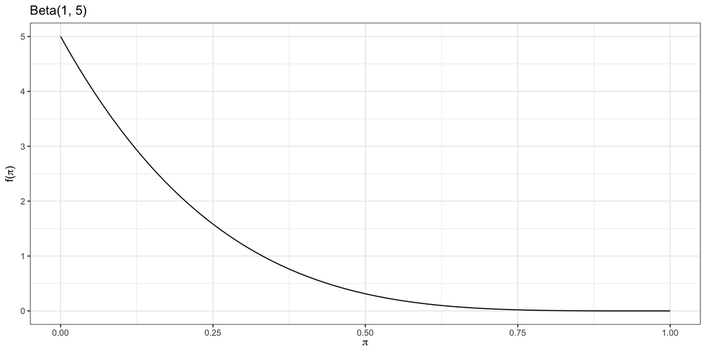

```r
plot_beta(1, 5) + theme_bw() + ggtitle("Beta(1, 5)")
```

## Beta Prior

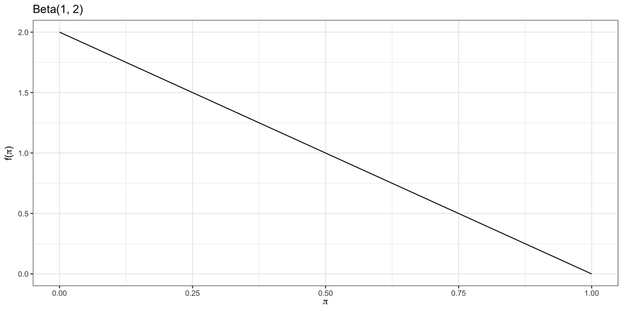

```r
plot_beta(1, 2) + theme_bw() + ggtitle("Beta(1, 2)")
```

## Beta Prior

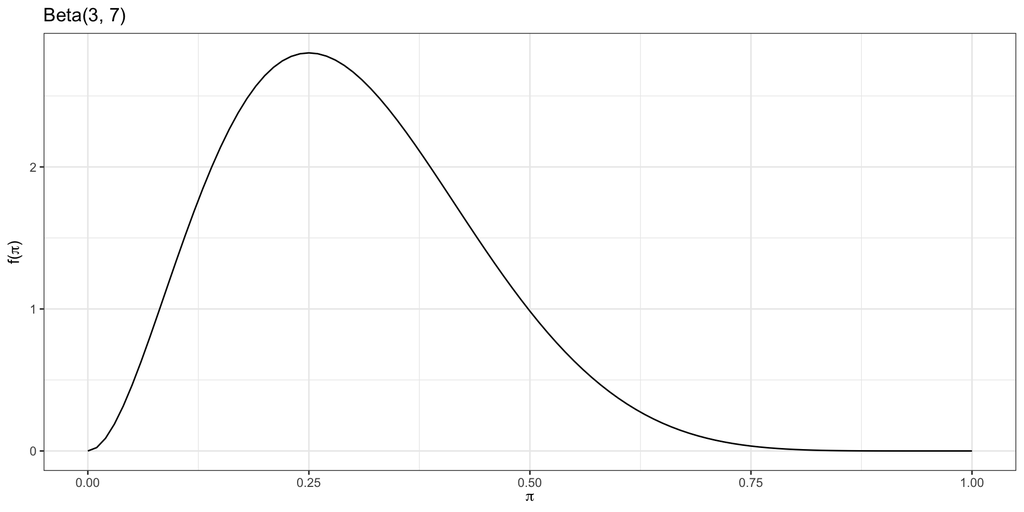

```r
plot_beta(3, 7) + theme_bw() + ggtitle("Beta(3, 7)")
```

## Beta Prior

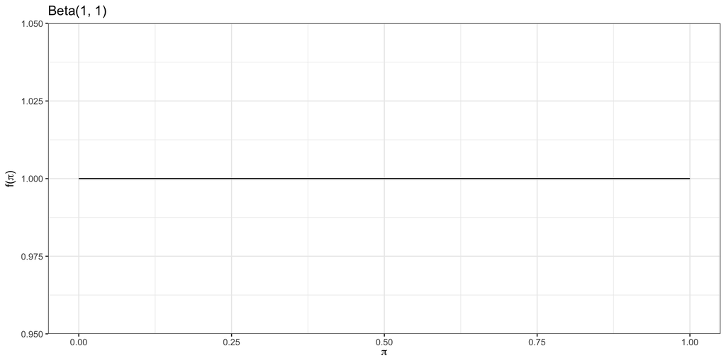

```r
plot_beta(1, 1) + theme_bw() + ggtitle("Beta(1, 1)")
```

## Beta Prior

- Your turn!
- How would you describe the typical behavior of a:
  - Beta($\alpha, \beta$) variable, $\pi$, when $\alpha=\beta$?
  - Beta($\alpha, \beta$) variable, $\pi$, when $\alpha>\beta$?
  - Beta($\alpha, \beta$) variable, $\pi$, when $\alpha<\beta$?
- For which model is there greater variability in the plausible values of $\pi$, Beta(20, 20) or Beta(5, 5)?

## Tuning the Beta Prior

$$E[\pi] = \frac{\alpha}{\alpha+\beta} \approx 0.45$$

- Using algebra, we can tune, and find

$$\alpha \approx \frac{9}{11} \beta$$

## Tuning the Beta Prior

- Your turn!
  - Graph the following and determine which is best for the example.

```r
plot_beta(9, 11) + theme_bw()
plot_beta(27, 33) + theme_bw()
plot_beta(45, 55) + theme_bw()
```

## Tuning the Beta Prior

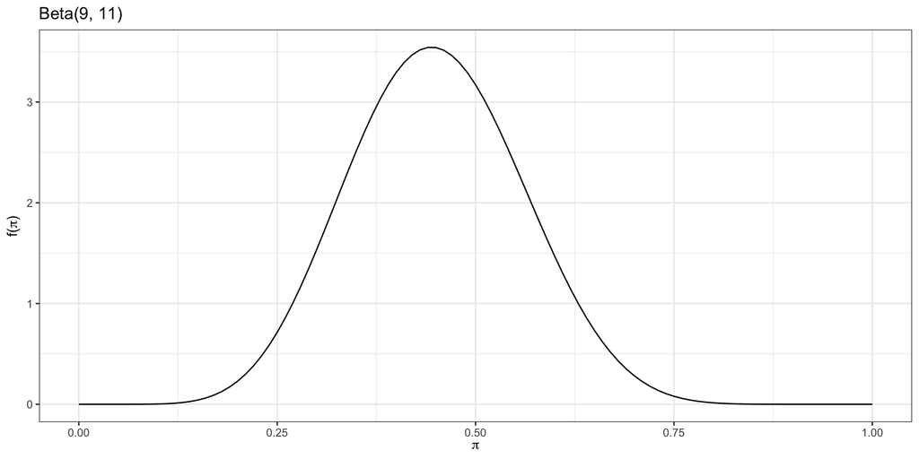

```r
plot_beta(9, 11) + theme_bw() + ggtitle("Beta(9, 11)")
```